# Project: Traffic Sign Recognition Classifier

### Self-Driving Car Engineer Nanodegree

[output not shown]

## Personal Thoughts

I am excited to work on this project. This is a wonderful opportunity for me to learn about the state-of-the-art technology, Deep Learning.

To tackle this project, I have been studying rigorously during my winter break. Well, the "break" they said. I finally understood what is Neural Network, Convolution Neural Networks, Back-propagation and few techniques to "fine-tune" my network including Adam Gradient Descent, Drop-out, Batch Normalization and Inception. While I understand that this is just a first step to the door, I am gratefully confident about the outcome of this class.

One important thing to note though: I feel that we do not have a quantitative model to validate the performance of CNN on real life. This is critical because human lives will be dependent on these CNNs, in term of autonomous vehicles. I hope I am wrong and we will figure it out soon! By then, it is hard to prove "how safe is safe" because I think 99% is not safe.

Now, let's dive into my steps of how to train the computer regonize Traffic Sign itself. Teehee :d

## Step 0: Load The Data

I used 'pickle' to load the data. There are training set and test set in dataset. In a perfect world, DO NOT TOUCH test set until you believe that your network is good enough.

The way I validated my network is to use cross-validation on minibatches. In particular, for every epoch, I divided my training set into 'BATCH_SIZE' (256) mini-batches. I used 20% of those batches as validation batches. I will go into detail about this in my 'network architechture'.

```python
# Load pickled data
import pickle
# TODO: Fill this in based on where you saved the training and testing data

training_file = '../data/train.p'
testing_file = '../data/test.p'

with open(training_file, mode='rb') as f:
    train = pickle.load(f)

with open(testing_file, mode='rb') as f:
    test = pickle.load(f)

X_train, y_train = train['features'], train['labels']
X_test, y_test = test['features'], test['labels']
```

## Step 1: Dataset Summary & Exploration

The pickled data is a dictionary with 4 key/value pairs:

- `'features'` is a 4D array containing raw pixel data of the traffic sign images, (num examples, width, height, channels).
- `'labels'` is a 2D array containing the label/class id of the traffic sign. The file `signnames.csv` contains id -> name mappings for each id.
- `'sizes'` is a list containing tuples, (width, height) representing the the original width and height the image.
- `'coords'` is a list containing tuples, (x1, y1, x2, y2) representing coordinates of a bounding box around the sign in the image. **THESE COORDINATES ASSUME THE ORIGINAL IMAGE. THE PICKLED DATA CONTAINS RESIZED VERSIONS (32 by 32) OF THESE IMAGES**

```python
### Replace each question mark with the appropriate value.
n_train = X_train.shape[0]
n_test = X_test.shape[0]
image_shape = (X_train.shape[1], X_train.shape[2], X_train.shape[3])
n_classes = len(set(y_train))
print("Number of training examples =", n_train)
print("Number of testing examples =", n_test)
print("Image data shape =", image_shape)
print("Number of classes =", n_classes)
```

```
Number of training examples = 39209
Number of testing examples = 12630
Image data shape = (32, 32, 3)
Number of classes = 43
```

The [Matplotlib](http://matplotlib.org/) [examples](http://matplotlib.org/examples/index.html) and [gallery](http://matplotlib.org/gallery.html) pages are a great resource for doing visualizations in Python.

```python
### Data exploration visualization goes here.
### Feel free to use as many code cells as needed.
# Visualizations will be shown in the notebook.
%matplotlib inline
import matplotlib.pyplot as plt
```

## Display few Traffic Sign Samples

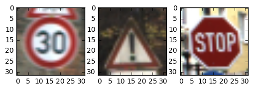

```python
plt.figure(1)
plt.subplot(131), plt.imshow(X_train[1000])
plt.subplot(132), plt.imshow(X_train[26000])
plt.subplot(133), plt.imshow(X_train[22700])
```

## Step 2: Design and Test a Model Architecture

Design and implement a deep learning model that learns to recognize traffic signs. Train and test your model on the [German Traffic Sign Dataset](http://benchmark.ini.rub.de/?section=gtsrb&subsection=dataset).

### Implementation

Use the code cell (or multiple code cells, if necessary) to implement the first step of your project. Once you have completed your implementation and are satisfied with the results, be sure to thoroughly answer the questions that follow.

#### 1. Data Pre-Processing and Data Augmentation

```python
# Perform Data Augmentation
import utils.data_processor as util
from pathlib import Path
import csv

#### NOTE ### I have applied data augmention on /data/train.p to train the network.
# I describe in detail in next section how I did it

# For now, just use original data since I have trained the CNN
train = util.load_data('../data/train.p')
X_train, y_train = train['features'], train['labels']

# Pre-process data
features = X_train/255                                        # scale pixel values to [0, 1]
#labels  = (y_train - len(set(y_train))) / len(set(y_train))  # scale label values to [-1, 1]
```

#### 2. Build and Traing The CNN

```python
from TrafficNet import TrafficNet

# Create A New Convolutional Neural Nets
conv_net = TrafficNet()
```

```python
# HYPER-PARAMETERS
EPOCHS = 5
LEARNING_RATE = 0.001
BATCH_SIZE = 256
KEEP_PROP = 0.65
ACCURATE_THRESHOLD = 0.991

# Train the Traffic Sign CNN on training set - It already reached ma
conv_net.train( features, y_train,
                save_loc='./model/vgg.chkpt',
                epochs=EPOCHS,
                learn_rate=LEARNING_RATE,
                batch_size=BATCH_SIZE,
                keep_prob=KEEP_PROP,
                acc_threshold=ACCURATE_THRESHOLD)
```

[output not shown]

#### 3. Test the CNN

```python
test = util.load_data('../data/test.p')
X_test, y_test = test['features'], test['labels']
X_test = X_test/255
#  Test the Traffic_Sign_CNN using test set
conv_net.test(X_test, y_test, model='./model/vgg.chkpt', batch_size=256)
```

```
Start Testing...
Restored Model Successfully.
Testing on 12630 samples
Test Accuracy = 0.9707

Finished Testing. Model is not saved
```

## Question 1

**Answer:**

1. Perform Data Augmentation with shear, rotate, changing brightness on original image.
2. Scale images from (0->255) to (0->1).

I have considered using grayscale. However, I want to keep the color channels on original image (32x32x3). All methods related to process data is stored in `utils/data_processor.py`.

#### Why do I think data agumentation is important?

Short answer is data set distribution. Each traffic sign has different amount of data. If the '20KM' traffic sign has more data than '70KM' sign, the network will be more biased toward the '20KM' sign. Let's look at the data distrubution of German Traffic Sign Data Set

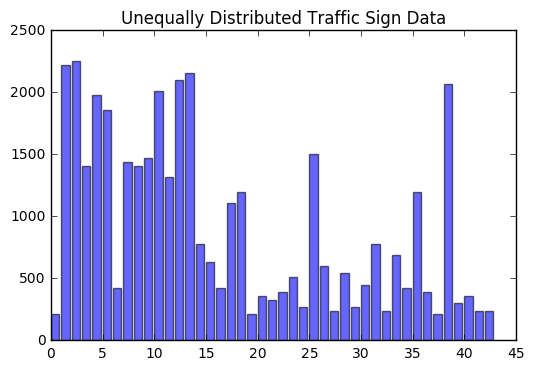

```python
import numpy as np
# Create a barchart of frequencies
item, count = np.unique(y_train, return_counts=True)
freq = np.array((item, count)).T
plt.bar(item, count, alpha=0.6)
plt.title('Unequally Distributed Traffic Sign Data')
```

### Question 2

*Describe how you set up the training, validation and testing data for your model. **Optional**: If you generated additional data, how did you generate the data? Why did you generate the data? What are the differences in the new dataset (with generated data) from the original dataset?*

**Answer:**

#### How did I perform Data Augmentation?

1. Define few image transformation methods (rotation, shift, shear, blurr , change gamma).
2. Define a method `random_transform()` to randomly apply multiple transformation on one image.
3. Define a `augment_data()` method to perform data augmentation on original data set.

Since the traffic sign samples is not distrubted equally, this could affect the CNN's performance. The network would be biased toward classes with more samples. **Data Augmentation** generates additional data on each traffic sign. For example, if the average sample for each classes is 1000 images. Any class has less than 300 images need to generate more data.

Data Augmentation includes but not limited to *blurring, rotating, shearing, translating, changing brighness* on original images. For image transformation, I found this documentation from [OpenCV](http://docs.opencv.org/trunk/da/d6e/tutorial_py_geometric_transformations.html) is helpful:

Also, [This library](https://github.com/aleju/imgaug) seems promising. However, I want to implement the code once before using it.

#### 1. Image Transformation Methods

We need to write some methods to transform orginal image. Below are my proposed methods: translation, rotation, affirm transformation, blur, brighten, darken an image. All the methods will generate new image at different random levels.

```python
import cv2
import numpy as np

def translate(img):
    "Shift orginal image around within image size"
    x = img.shape[0]
    y = img.shape[1]
    x_shift = np.random.uniform(-0.3 * x, 0.3 * x)
    y_shift = np.random.uniform(-0.3 * y, 0.3 * y)
    shift_matrix = np.float32([[1, 0, x_shift], [0, 1, y_shift]])
    shift_img = cv2.warpAffine(img, shift_matrix, (x, y))
    return shift_img

def rotate(img):
    " Rotate original image at random rotation angle from -90 degree to +90 degree"
    row, col, channel = img.shape
    angle = np.random.uniform(-90, 90)
    rotation_point = (row / 2, col / 2)
    rotation_matrix = cv2.getRotationMatrix2D(rotation_point, angle, 1)
    rotated_img = cv2.warpAffine(img, rotation_matrix, (col, row))
    return rotated_img

def shear(img):
    " Affirm Transformation orignal image"
    x, y, channel = img.shape
    shear = np.random.randint(5,15)
    pts1 = np.array([[5, 5], [20, 5], [5, 20]]).astype('float32')
    pt1 = 5 + shear * np.random.uniform() - shear / 2
    pt2 = 20 + shear * np.random.uniform() - shear / 2
    pts2 = np.float32([[pt1, 5], [pt2, pt1], [5, pt2]])
    M = cv2.getAffineTransform(pts1, pts2)
    result = cv2.warpAffine(img, M, (y, x))
    return result

def blur(img):
    r_int = np.random.randint(0, 2)
    odd_size = 2 * r_int + 1
    return cv2.GaussianBlur(img, (odd_size, odd_size), 0)


def gamma(img):
    gamma = np.random.uniform(0.2, 1.5)
    invGamma = 1.0 / gamma
    table = np.array([((i / 255.0) ** invGamma) * 255 for i in np.arange(0, 256)]).astype("uint8")
    new_img = cv2.LUT(img, table)
    return new_img

def random_transform(img):
    # There are total of 6 transformation
    # I will create an boolean array of 6 elements [ 0 or 1]
    a = np.random.randint(0, 2, [1, 5]).astype('bool')[0]
    if a[0] == 1: img = translate(img)
    if a[1] == 1: img = rotate(img)
    if a[2] == 1: img = shear(img)
    if a[3] == 1: img = blur(img)
    if a[4] == 1: img = gamma(img)

    return img
```

Let's test on a sample. I generate 5 images per transformation on a random image of training set.

[figure not shown]

```python
i = 22700
sample_1 = X_train[i]
translated_img = []
rotated_img = []
shear_img = []
blur_img = []
noise_img = []
gamma_img=[]
for i in range(5):
    translated_img.append(translate(sample_1)),rotated_img.append(rotate(sample_1))
    shear_img.append(shear(sample_1)), blur_img.append(blur(sample_1)), gamma_img.append(gamma(sample_1))

row, col = 5, 5
plt.figure(2)
plt.subplot(row, col,1), plt.title('Shift'), plt.subplot(row, col,2), plt.title('Rotation')
plt.subplot(row, col,3), plt.title('Shear'), plt.subplot(row, col,4), plt.title('Blur')
plt.subplot(row, col,5), plt.title('Gamma')

for i in range(5):
    pos = 5*i
    plt.subplot(row, col,pos+1), plt.imshow(translated_img[i]),  plt.axis('off')
    plt.subplot(row, col,pos+2), plt.imshow(rotated_img[i]), plt.axis('off')
    plt.subplot(row, col,pos+3), plt.imshow(shear_img[i]), plt.axis('off')
    plt.subplot(row, col,pos+4), plt.imshow(blur_img[i]), plt.axis('off')
    plt.subplot(row, col,pos+5), plt.imshow(gamma_img[i]), plt.axis('off')
```

[figure not shown]

```python
# Apply multiple transformations on one image
for j in range(5):
    pos=5*j
    for i in range(8):
        test = random_transform(sample_1)
        plt.subplot(5, 7, pos+i+1), plt.imshow(test), plt.axis('off')
```

### 2. Generate New Dataset using Image Transformation.

We have a way to generate additional data now. However, each class in dataset should have different needed amount of additional data. All of the following code has been encasuplated in **`utils.data_processor.py`**

##### 2.1 Separate Traffic Sign Data Set:

For every traffic sign, I decided to place in different arrays so that I could expand these later.

```python
# Based on that average, we can estimate how many images a traffic sign need to have
total_traffic_signs = len(set(y_train))
# Calculate how many images in one traffic sign
ts, imgs_per_sign = np.unique(y_train, return_counts=True)
avg_per_sign = np.ceil(np.mean(imgs_per_sign)).astype('uint32')

separated_data = []
for traffic_sign in range(total_traffic_signs):
    images_in_this_sign = X_train[y_train == traffic_sign,...]
    separated_data.append(images_in_this_sign)
```

##### 2.2 Generate New Data Set on Each Traffic Sign:

**This step takes some time. Please be patient!**

**Disable the comment by `'Ctrl + /'` if you want to run.**

```python
# # Second, for each dataset, I generate new images randomly based on current total images
# expanded_data = np.array(np.zeros((1, 32,32,3)))
# expanded_labels = np.array([0])

# for sign, sign_images in enumerate(separated_data):
#     scale_factor = (4*(avg_per_sign/imgs_per_sign[sign])).astype('uint32')
#     new_images = []
#     # Generate new images  <---- Could apply list comprehension here
#     for img in sign_images:
#         for _ in range(scale_factor):
#             new_images.append(random_transform(img))
#     # Add old images and new images into 1 array
#     if len(new_images) > 0:
#         sign_images = np.concatenate((sign_images, new_images),axis=0)
#     new_labels = np.full(len(sign_images),sign, dtype ='uint8')
#     # Insert new_images to current dataset
#     expanded_data = np.concatenate((expanded_data,sign_images), axis = 0)
#     expanded_labels = np.concatenate((expanded_labels, new_labels), axis=0)
```

#### Compare Before and After Data Augmentation

```python
# # Create a barchart of frequencies
# item, count = np.unique(y_train, return_counts=True)
# freq = np.array((item, count)).T
# item2, count2 = np.unique(expanded_labels, return_counts=True)
# freq2 = np.array((item2, count2)).T

# plt.figure(figsize=(15, 5))
# before = plt.subplot(1,2, 1)
# after = plt.subplot(1,2,2)
# before.bar(item, count, alpha=0.4), after.bar(item2, count2, alpha=0.8)
# before.set_title("Before: Unequally distributed data", size=12)
# after.set_title("After: Equally distributed data", size=12)
```

### Question 3

*What does your final architecture look like? (Type of model, layers, sizes, connectivity, etc.) For reference on how to build a deep neural network using TensorFlow, see Deep Neural Network in TensorFlow from the classroom.*

**Answer:**

My architecture is :

Here is the visualization of how my Convolutional Neural Networks is look like.

[figure not shown]

### Question 4 :

How did you train your model? (Type of optimizer, batch size, epochs, hyperparameters, etc.)

##### **Answer:**

#### Weight Initialization:

- xavier_initializer (tf.contrib.layers.xavier_initializer())

#### Optimizer :

- **Adam Optimizer**: According to CS231n, I found that Adam Optimizer provides good performance compared to others like RMSProp, Adagrad or Momentum.

### Question 5

*What approach did you take in coming up with a solution to this problem? It may have been a process of trial and error, in which case, outline the steps you took to get to the final solution and why you chose those steps. Perhaps your solution involved an already well known implementation or architecture. In this case, discuss why you think this is suitable for the current problem.*

**Answer:**

#### 1. Architect a good CNN

I mostly researched on how to build a good model architecture. However, I think it is a waste. As Andrej mention in [here](http://cs231n.github.io/convolutional-networks/#comp). "Don't be a hero". It is good to see what works best and start from there.

I spent most of the time to figure out how many layers should I use, how many filters should be in 1 convolution layer and waiting for it to train.

Finally, I decided to follow VGG-16 architect due to its simplicty and straight-forward. However, I reduced a layers to perform faster at training time. I think that is okay because the size of our dataset is not as big as ImageNet so we actually do not need a really big CNN.

#### 2. Fine-tune parameters

I found that setting the learning rate decay is very important. I made a mistake that I set the decay decreases too fast so the first layers of my network barely updated and I thought my network is not good enough.

Drop-out magically boosted the accuracy. I attemped to try L1, L2 regularization but the result is not as good as drop-out. I set closer layers to the output having higher drop-out rate, as it has been suggested in [here](http://danielnouri.org/notes/2014/12/17/using-convolutional-neural-nets-to-detect-facial-keypoints-tutorial/#dropout)

#### 3. Debugging

I had to face some challenges with TensorFlow. The way they instaniate Variables is weird (or might be I don't get their concepts, yet). It requires to have some name_scope to know which weights/biases Variables belong to which layers.

Due to dropout, my network seems to give me different accuracy on the same test set every time I run it. It is annoying, but I think it is okay because it does not fluctuate a lot ( ~ 0.1% -> 0.3%)

## Step 3: Test a Model on New Images

Take several pictures of traffic signs that you find on the web or around you (at least five), and run them through your classifier on your computer to produce example results. The classifier might not recognize some local signs but it could prove interesting nonetheless.

You may find `signnames.csv` useful as it contains mappings from the class id (integer) to the actual sign name.

### Implementation

```python
# Map ClassID to traffic sign names
signs = []
with open('signnames.csv', 'r') as csvfile:
    signnames = csv.reader(csvfile, delimiter=',')
    next(signnames,None)
    for row in signnames:
        signs.append(row[1])
    csvfile.close()
```

```python
# Load and resize image
import os
test_images = []
path = './test_images/'

for image in os.listdir(path):
    img = cv2.imread(path + image)
    img = cv2.resize(img, (32,32))
    img = cv2.cvtColor(img, cv2.COLOR_BGR2RGB)
    test_images.append(img)

# Display shape of test images and pre-process
test_images = np.array(test_images)
test_images = test_images/255
```

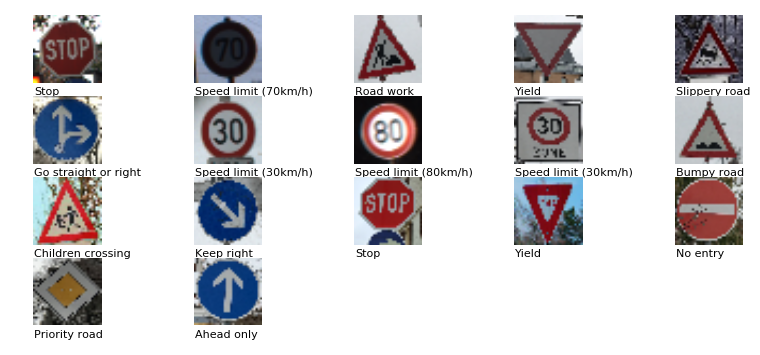

```python
# 1. Calculate softmax predictions
softmax_scores = conv_net.predict(test_images, saved_model='./model/vgg.chkpt')
# From the softmax, I calculated which classID is max.
result = np.array([i.argmax() for i in softmax_scores])
plt.figure(figsize=(10,4))
for i, image in enumerate(test_images):
    grid = plt.subplot(len(test_images)/4,5,i+1)
    grid.imshow(image), plt.axis('off')
    # Label the prediction result
    grid.annotate(signs[result[i]], (0, 0), (0, image.shape[0]+5), size=8)
```

### Question 6

*Choose five candidate images of traffic signs and provide them in the report. Are there any particular qualities of the image(s) that might make classification difficult? It could be helpful to plot the images in the notebook.*

**Answer:**

```
Normalized confusion matrix
```

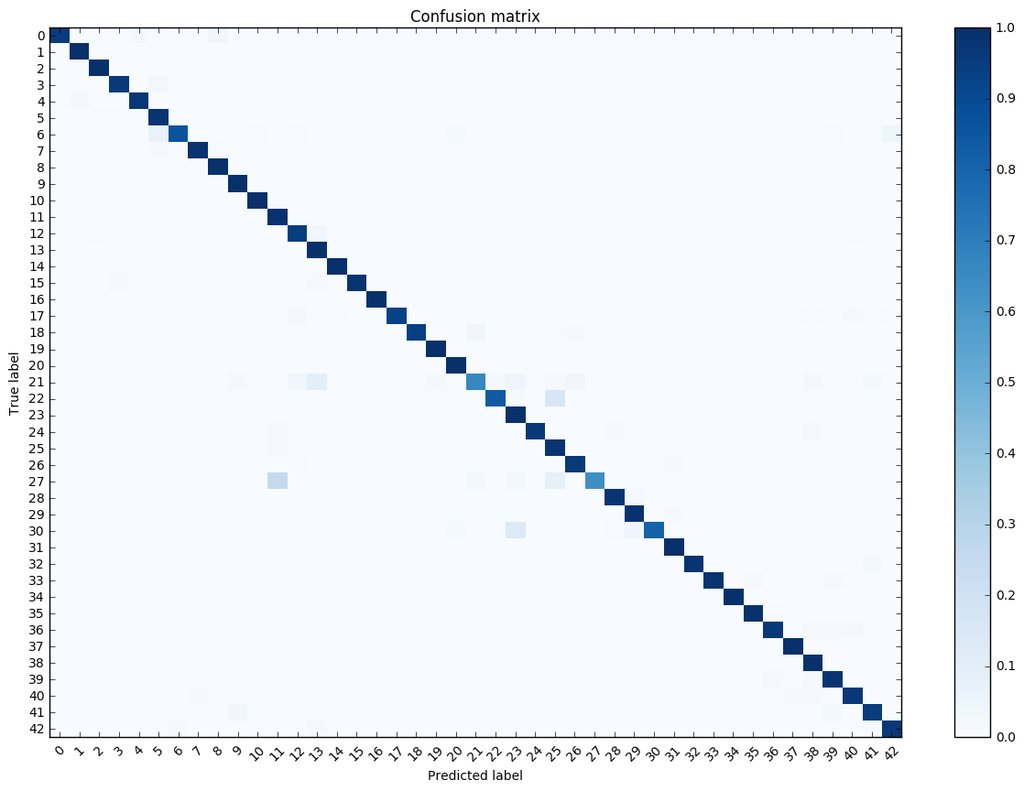

```python
correct_predictions = conv_net.score(X_test, y_test, model='./model/vgg.chkpt', plot=True, normalize=True)
```

[output not shown]

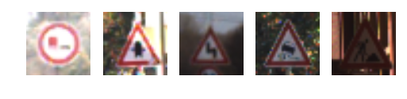

```python
# Let's see how the images look like in training set
plt.subplot(1,5,1), plt.imshow(X_train[y_train==10][100]), plt.axis('off')
plt.subplot(1,5,2),plt.imshow(X_train[y_train==11][100]),plt.axis('off')
plt.subplot(1,5,3),plt.imshow(X_train[y_train==21][100]),plt.axis('off')
plt.subplot(1,5,4),plt.imshow(X_train[y_train==23][100]),plt.axis('off')
plt.subplot(1,5,5),plt.imshow(X_train[y_train==25][100]),plt.axis('off')

# You might notice that the 10 is really hard to detect even
# by human eyes (At least in my case).
```

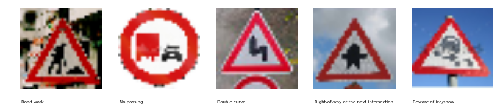

```python
# I went online and downloaded few test images.
# Let's see how it performs
import os
path = './difficult_images/'
hard_imgs = []
for image in os.listdir(path):
    img = cv2.imread(path + image)
    img = cv2.resize(img, (32,32))
    img = cv2.cvtColor(img, cv2.COLOR_BGR2RGB)
    hard_imgs.append(img)

# Display shape of test images and pre-process
hard_imgs = np.array(hard_imgs)
hard_imgs = hard_imgs/255

# 1. Calculate softmax predictions
softmax_scores = conv_net.predict(hard_imgs, saved_model='./model/vgg.chkpt')
# From the softmax, I calculated which classID is max.
result = np.array([i.argmax() for i in softmax_scores])

plt.figure(figsize=(10,15))
for i, image in enumerate(hard_imgs):
    grid = plt.subplot(len(hard_imgs)/1,5,i+1)
    grid.imshow(image), plt.axis('off')
    # Label the prediction result
    grid.annotate(signs[result[i]], (0, 0), (0, image.shape[0]+5), size=5)
```

### Question 7

*Is your model able to perform equally well on captured pictures when compared to testing on the dataset? The simplest way to do this check the accuracy of the predictions. For example, if the model predicted 1 out of 5 signs correctly, it's 20% accurate.*

**NOTE:** You could check the accuracy manually by using `signnames.csv` (same directory). This file has a mapping from the class id (0-42) to the corresponding sign name. So, you could take the class id the model outputs, lookup the name in `signnames.csv` and see if it matches the sign from the image.

It performs fairly well on test images (~ 97%). However, if the sign is one of the difficult images like above, the accuracy will drop (~80%). I think it is important to augment more data on these specific datasets to make my model better.

For now, I satisfy with most of the predictions. As one might see, the accuracy on Question 5 is 100% and around 80% for difficult images.

### Question 8

*Use the model's softmax probabilities to visualize the **certainty** of its predictions, [`tf.nn.top_k`](https://www.tensorflow.org/versions/r0.12/api_docs/python/nn.html#top_k) could prove helpful here. Which predictions is the model certain of? Uncertain? If the model was incorrect in its initial prediction, does the correct prediction appear in the top k? (k should be 5 at most)*

`tf.nn.top_k` will return the values and indices (class ids) of the top k predictions. So if k=3, for each sign, it'll return the 3 largest probabilities (out of a possible 43) and the correspoding class ids.

**Answer:**

One strange thing is that the soft_max changes every time I run the predictions. I think due to the drop_out every time. I might need to investigate further to understand why it happens.

```python
### Visualize the softmax probabilities here.
top_k = conv_net.top_k(hard_imgs,saved_model='./model/vgg.chkpt')

### Here is my visualize softmax implementation. However, I have encapsulated these methods in TrafficNet object

# def top_k(imgs, k=3, saved_model='./model/vgg.chkpt'):
#     top_k = tf.nn.top_k(self.logits, k=k)
#     with tf.Session() as sess:
#         tf.train.Saver().restore(sess, saved_model)
#         prob, id = sess.run(top_k, feed_dict={self.features: imgs})
#     return prob, id

# def visualize_softmax(imgs, signs, saved_model, correct_predictions=None, top_k=3):

#     probs, id = self.top_k(imgs, top_k, saved_model)
#     probs = np.exp(probs)
#     y_pos = np.arange(top_k)
#     for i in range(len(imgs)):
#         plt.figure(i+1, figsize=(15, 5))
#         img = plt.subplot(1, 2, 1)
#         img.imshow(imgs[i])
#         if correct_predictions is not None:
#             img.set_title("Correct sign: " + correct_predictions[i])
#         pred = plt.subplot(1, 2, 2)
#         pred.barh(y_pos, probs[i], color='red')
#         pred.set_yticks(y_pos)
#         pred.set_yticklabels([signs[j] for j in id[i]])
#         pred.set_xlabel("Probabilities")
#         plt.tight_layout()
#         plt.setp(pred.get_xticklabels(), visible=False)
#     plt.show()
```

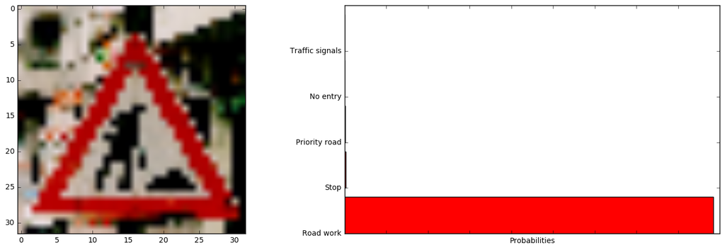

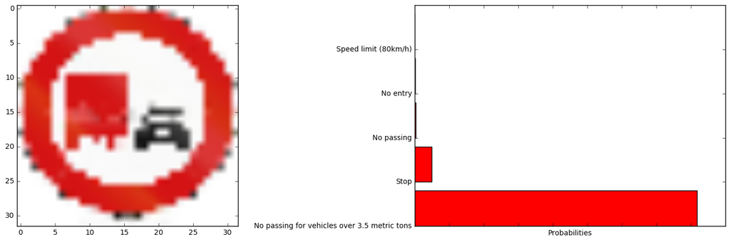

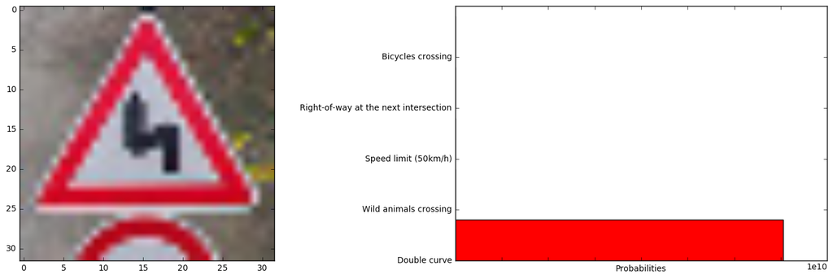

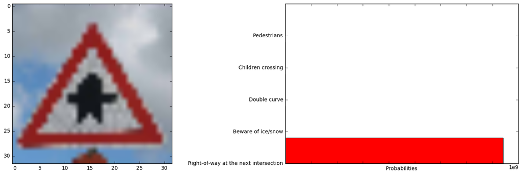

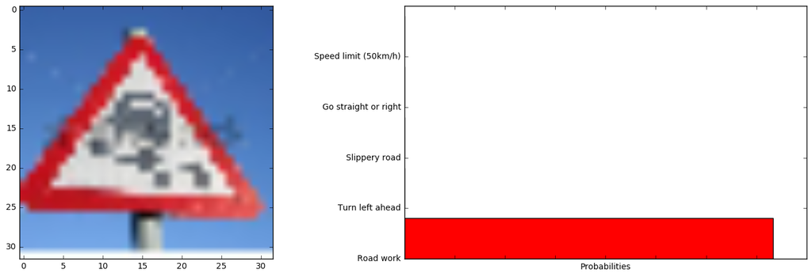

```python
conv_net.visualize_softmax(hard_imgs,signs,saved_model='./model/vgg.chkpt',top_k=5)
```